# ML Algorithms for classification

Decision trees

Hicham Zmarrou

Notebook – http://bit.ly/2q9NPSU

[Visit my website](http://trefoil.ml/) for more like this!

## Exercise 1

Consider the Kyphosis data frame(type `help("kyphosis")` for more details), that contains: -Kyphosis:a factor with levels absent present indicating if a kyphosis (a type of deformation) was present after the operation. -Age:in months. -Number:the number of vertebrae involved. -Start:the number of the first (topmost) vertebra operated on.

```r
library('rattle')
library('rpart')
library("rpart.plot")
TREE=rpart(Kyphosis ~ Age + Number + Start, data=kyphosis,method="class")
#TREE
#fancyRpartPlot(TREE)
asRules(TREE)
```

```
 Rule number: 3 [Kyphosis=present cover=19 (23%) prob=0.58]
   Start< 8.5

 Rule number: 23 [Kyphosis=present cover=7 (9%) prob=0.57]
   Start>=8.5
   Start< 14.5
   Age>=55
   Age< 111

 Rule number: 22 [Kyphosis=absent cover=14 (17%) prob=0.14]
   Start>=8.5
   Start< 14.5
   Age>=55
   Age>=111

 Rule number: 10 [Kyphosis=absent cover=12 (15%) prob=0.00]
   Start>=8.5
   Start< 14.5
   Age< 55

 Rule number: 4 [Kyphosis=absent cover=29 (36%) prob=0.00]
   Start>=8.5
   Start>=14.5
```

`cover= xx` means there are `xx` records split into that path (branch) of the tree at that node.

1. Build a tree to classify Kyphosis from Age, Number and Start

## Exercise 2

Consider the tree build in exercise 1. 1) Which variables are used to explain kyhosis presence? 2) How many observations contains the terminal nodes.

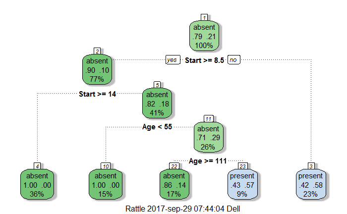

```r
fancyRpartPlot(TREE)
```

```r
TREE
```

```
n= 81

node), split, n, loss, yval, (yprob)
      * denotes terminal node

 1) root 81 17 absent (0.79012346 0.20987654)
   2) Start>=8.5 62  6 absent (0.90322581 0.09677419)
     4) Start>=14.5 29  0 absent (1.00000000 0.00000000) *
     5) Start< 14.5 33  6 absent (0.81818182 0.18181818)
      10) Age< 55 12  0 absent (1.00000000 0.00000000) *
      11) Age>=55 21  6 absent (0.71428571 0.28571429)
        22) Age>=111 14  2 absent (0.85714286 0.14285714) *
        23) Age< 111 7  3 present (0.42857143 0.57142857) *
   3) Start< 8.5 19  8 present (0.42105263 0.57894737) *
```

```r
printcp(TREE)
```

```
Classification tree:
rpart(formula = Kyphosis ~ Age + Number + Start, data = kyphosis,
    method = "class")

Variables actually used in tree construction:
[1] Age   Start

Root node error: 17/81 = 0.20988

n= 81

        CP nsplit rel error xerror    xstd
1 0.176471      0   1.00000 1.0000 0.21559
2 0.019608      1   0.82353 1.0000 0.21559
3 0.010000      4   0.76471 1.0588 0.22010
```

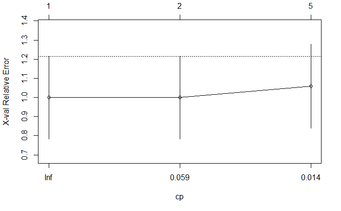

```r
plotcp(TREE)
```

## Exercise 3

Consider the Kyphosis data frame. 1)Build a tree using the first 60 observations of kyphosis.

```r
TREE=rpart(Kyphosis ~ Age + Number + Start, data=kyphosis[1:60,],method="class")
```

2)Predict the kyphosis presence for the other 21 observations.

```r
PR=predict(TREE,kyphosis[61:81,],type='class')
```

3)Which is the misclassification rate (prediction error)

```r
test=kyphosis$Kyphosis[61:81]
table(PR,test)
```

```
         test
PR        absent present
  absent      14       2
  present      3       2
```

```r
rate=100*length(which(PR!=test))/length(PR)
```

The misclassification rate is: 23.8095238

## Exercise 4

Consider the iris data frame(type `help('iris')` for more details). 1)Build a tree to classify Species from the other variables.

```r
TREE2=rpart(Species ~ ., data=iris,method="class")
TREE2
```

```
n= 150

node), split, n, loss, yval, (yprob)
      * denotes terminal node

1) root 150 100 setosa (0.33333333 0.33333333 0.33333333)
  2) Petal.Length< 2.45 50   0 setosa (1.00000000 0.00000000 0.00000000) *
  3) Petal.Length>=2.45 100  50 versicolor (0.00000000 0.50000000 0.50000000)
    6) Petal.Width< 1.75 54   5 versicolor (0.00000000 0.90740741 0.09259259) *
    7) Petal.Width>=1.75 46   1 virginica (0.00000000 0.02173913 0.97826087) *
```

2)Plot the trees.

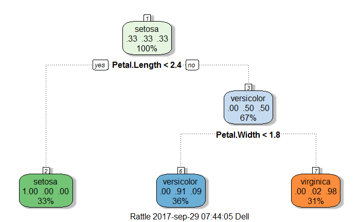

```r
fancyRpartPlot(TREE2)
```

## Exercise 5

Consider the tree build in exercise 4. 1) Prune the the using median complexity parameter (cp) associated to the tree.

```r
TP=prune(TREE2,cp=median(TREE2$cptable[,'CP']))
```

2. Plot in the same window the pruned and the original tree.

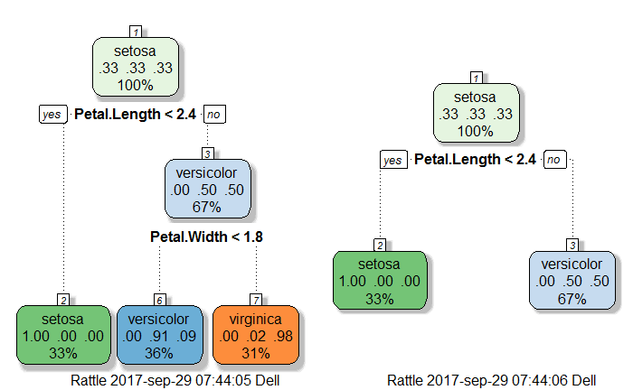

```r
par(mfrow=c(1,2))
fancyRpartPlot(TREE2)
fancyRpartPlot(TP)
```

## Exercise 6

Consider the tree build in exercise 4. 1)In which terminal nodes is clasified each observations of iris?

```r
TREE2$where
```

```
  1   2   3   4   5   6   7   8   9  10  11  12  13  14  15  16  17  18  19  20  21  22
  2   2   2   2   2   2   2   2   2   2   2   2   2   2   2   2   2   2   2   2   2   2
 23  24  25  26  27  28  29  30  31  32  33  34  35  36  37  38  39  40  41  42  43  44
  2   2   2   2   2   2   2   2   2   2   2   2   2   2   2   2   2   2   2   2   2   2
 45  46  47  48  49  50  51  52  53  54  55  56  57  58  59  60  61  62  63  64  65  66
  2   2   2   2   2   2   4   4   4   4   4   4   4   4   4   4   4   4   4   4   4   4
 67  68  69  70  71  72  73  74  75  76  77  78  79  80  81  82  83  84  85  86  87  88
  4   4   4   4   5   4   4   4   4   4   4   4   4   4   4   4   4   4   4   4   4   4
 89  90  91  92  93  94  95  96  97  98  99 100 101 102 103 104 105 106 107 108 109 110
  4   4   4   4   4   4   4   4   4   4   4   4   5   5   5   5   5   5   4   5   5   5
111 112 113 114 115 116 117 118 119 120 121 122 123 124 125 126 127 128 129 130 131 132
  5   5   5   5   5   5   5   5   5   4   5   5   5   5   5   5   5   5   5   4   5   5
133 134 135 136 137 138 139 140 141 142 143 144 145 146 147 148 149 150
  5   4   4   5   5   5   5   5   5   5   5   5   5   5   5   5   5   5
```

2)Which Specie has a flower of Petal.Length greater than 2.45 and Petal.Width less than 1.75.

## Exercise 7

Consider the car90 data frame(type help(‘car90’) for more details). 1)Build a tree to predict Price from the other variables.

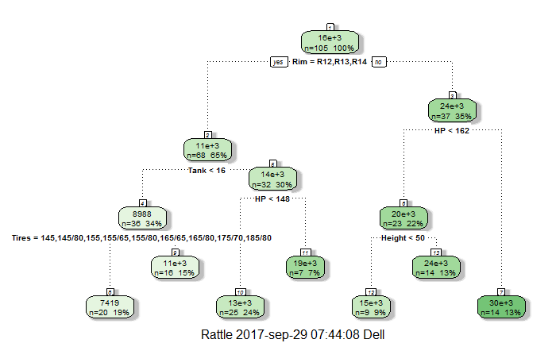

```r
tree=rpart(Price ~ ., data=car90,method="anova")
fancyRpartPlot(tree)
```

2)Plot the trees, add nodes information.

## Exercise 8

Consider the tree build in exercise 7. 1) Which variables are used to explain the price?

```r
#tree
#printcp(tree)
asRules(tree)
```

```
 Rule number: 10 [Price=13014.72 cover=25 (24%)]
   Rim=R12,R13,R14
   Tank>=15.65
   HP< 147.5

 Rule number: 8 [Price=7419.05 cover=20 (19%)]
   Rim=R12,R13,R14
   Tank< 15.65
   Tires=145,145/80,155,155/65,155/80,165/65,165/80,175/70,185/80

 Rule number: 9 [Price=10949.8125 cover=16 (15%)]
   Rim=R12,R13,R14
   Tank< 15.65
   Tires=185/60,185/70,195/60,195/70,195/75,205/75

 Rule number: 7 [Price=29643.0714285714 cover=14 (13%)]
   Rim=R15,R16,R17
   HP>=162.5

 Rule number: 13 [Price=23614.2857142857 cover=14 (13%)]
   Rim=R15,R16,R17
   HP< 162.5
   Height>=49.75

 Rule number: 12 [Price=14755 cover=9 (9%)]
   Rim=R15,R16,R17
   HP< 162.5
   Height< 49.75

 Rule number: 11 [Price=18886.2857142857 cover=7 (7%)]
   Rim=R12,R13,R14
   Tank>=15.65
   HP>=147.5
```

2)Which terminal nodes have a value of mean Price, less than mean(car90$Price)?

```r
summary(tree)
```

[output not shown]

## Exercise 9

Consider the car.test.frame data frame (type help(‘car.test.frame’) for more details). 1)Build a tree to explain Mileage using the other variables.

```r
TC=rpart(Mileage~., data=car.test.frame)
TC
```

[output not shown]

2)Snip the tree in nodes number 2.

```r
TS=snip.rpart(TC,toss=2)
```

3)Plot both tree together

```r
fancyRpartPlot(TC)
```

[output not shown]

## Exercise 10

Consider the tree build in exercise 9. 2). Which is the depth of the tree (with the root node counted as depth 0). 3). Set the maximum depth of the final tree on 2

```r
TC2=rpart(Mileage~., data=car.test.frame,maxdepth=2)
fancyRpartPlot(TC2)
```

[output not shown]

```r
#plot both together
par(mfrow=c(1,2))
fancyRpartPlot(TC)
fancyRpartPlot(TC2)
```

[output not shown]